# Homework 3

Joshua Carpenter

## Data and Description

Climate change has left California particularly vulnerable to severe drought conditions. One factor affecting water availability in Southern California is stream runoff from snowfall (FYI: water in Utah is also heavily reliant on snowpack). If runoff could be predicted, engineers, planners, and policy makers could do their jobs more effectively because they would have an estimate as to how much water is entering the area.

The Runoff Water data set compares the **stream runoff (column 2)** (in acre-feet) of a river near Bishop, California (due east of San Jose) with **snowfall (column 1)** (in inches) at a site in the Sierra Nevada mountains. The data set contains 43 years’ worth of measurements. Download the water.txt file from Canvas, and put it in the same folder as this R Markdown file.

#### 0. Replace the text “< PUT YOUR NAME HERE >” (above next to “author:”) with your full name.

#### 1. Read in the data set, and call the data frame “water”. Print a summary of the data and make sure the data makes sense.

```r
water <- read_table2("water.txt")
summary(water)
```

```
##      Precip           Runoff
##  Min.   : 4.600   Min.   : 41785
##  1st Qu.: 8.705   1st Qu.: 59857
##  Median :12.140   Median : 69177
##  Mean   :13.522   Mean   : 77756
##  3rd Qu.:16.920   3rd Qu.: 92206
##  Max.   :33.070   Max.   :146345
```

#### 2. Create (and print) a scatterplot of the data with variables on the appropriate axes. Make you plot look professional (make sure the axes have appropriate limits to capture the data nicely, make sure the axes labels are descriptive, etc.). You should save your plot as an object to be used throughout the rest of the assignment.

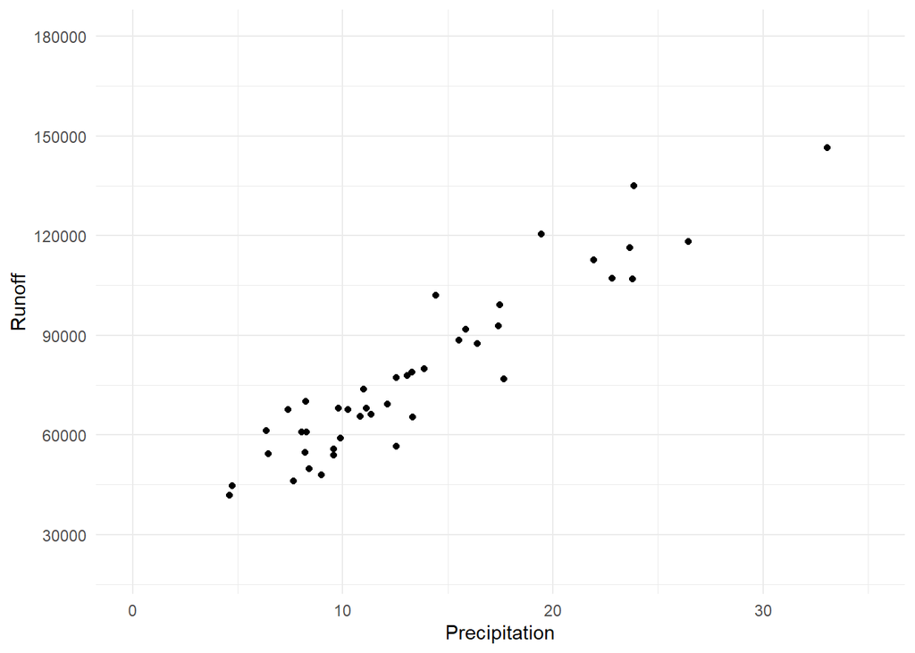

```r
(water.plot <-
  ggplot(data = water, mapping = aes(x = Precip, y = Runoff)) +
  geom_point() +
  xlab("Precipitation") +
  xlim(0, 35) +
  scale_y_continuous(limits = c(20000, 180000),
                     breaks = seq(30000, 180000, 30000)) +
  theme_minimal())
```

#### 3. Calculate (and print) the correlation coefficient. Use that and the scatterplot to briefly describe the relationship between Stream Runoff and Snowfall.

```r
cor(water$Precip, water$Runoff)
```

```
## [1] 0.938436
```

There is a very strong, positive, linear correlation between amount of precipitation and water runoff.

#### 4. Add the OLS regression line to the scatterplot you created in 2. Print the plot.

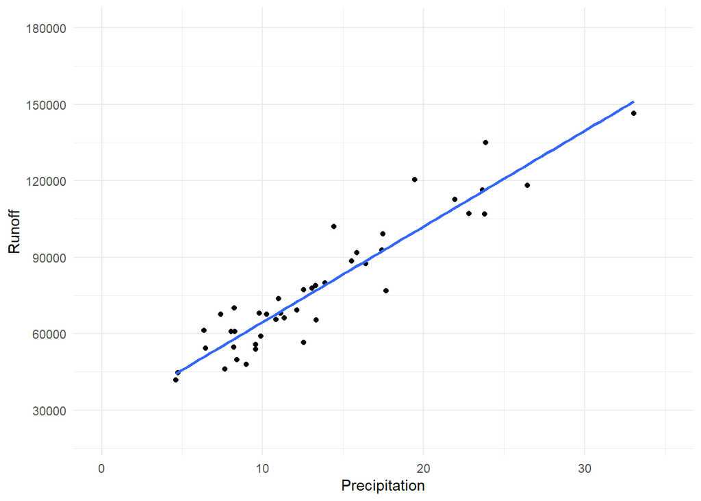

```r
water.plot +
  geom_smooth(method = "lm", se = FALSE)
```

#### 5. Fit a simple linear regression model to the data (no transformations), and save the residuals and fitted values to the `water` dataframe. Print a summary of the linear model.

```r
water.lm <- lm(Runoff ~ Precip, data = water)
water <- water %>%
  mutate(Resid = water.lm$residuals, Fit = water.lm$fitted.values)
summary(water.lm)
```

```
##
## Call:
## lm(formula = Runoff ~ Precip, data = water)
##
## Residuals:
##      Min       1Q   Median       3Q      Max
## -17603.8  -5338.0    332.1   3410.6  20875.6
##
## Coefficients:
##             Estimate Std. Error t value Pr(>|t|)
## (Intercept)  27014.6     3218.9   8.393 1.93e-10 ***
## Precip        3752.5      215.7  17.394  < 2e-16 ***
## ---
## Signif. codes:  0 '***' 0.001 '**' 0.01 '*' 0.05 '.' 0.1 ' ' 1
##
## Residual standard error: 8922 on 41 degrees of freedom
## Multiple R-squared:  0.8807, Adjusted R-squared:  0.8778
## F-statistic: 302.6 on 1 and 41 DF,  p-value: < 2.2e-16
```

### Questions 6 to 11 involve using diagnostics to determine if the linear regression assumptions are met. For each assumption, (1) perform appropriate diagnostics to determine if the assumption is violated, and (2) explain whether or not you think the assumption is violated and why you think that.

#### 6. (L) $X$ vs $Y$ is linear (use at least two diagnostic tools)

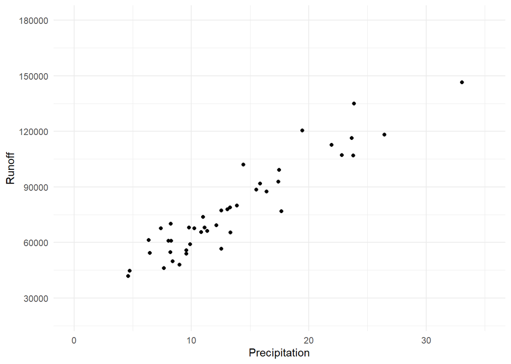

```r
# Scatterplot
water.plot
```

```r
#Residuals vs Fitted Values
(water.resid_fit <- autoplot(water.lm, which = 1, ncol = 1) +
    theme_minimal())
```

[output not shown]

#### 7. (I) The residuals are independent (no diagnostic tools - just think about how the data was collected and briefly write your thoughts)

There is definitely some dependency year to year. This assumption is not met.

#### 8. (N) The residuals are normally distributed and centered at zero (use at least three diagnostic tools)

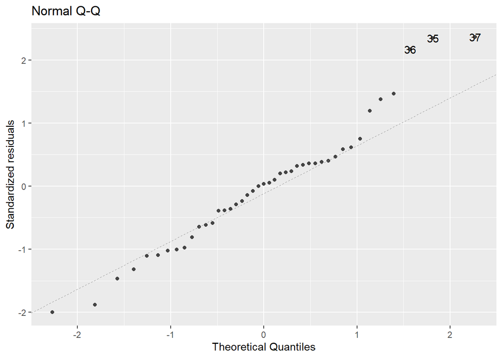

```r
# Q-Q
(water.qq <- autoplot(water.lm, which = 2, ncol = 1))
```

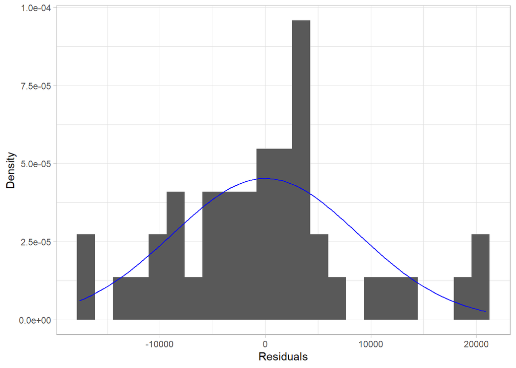

```r
# Histogram
ggplot(data = water, mapping = aes(x = Resid)) +
  geom_histogram(binwidth = 1700, mapping = aes(y = ..density..)) +
  stat_function(fun = dnorm,
                color = "blue",
                args = list(mean = 0,
                            sd = sd(water$Resid))) +
  xlab("Residuals") +
  ylab("Density") +
  theme_light()
```

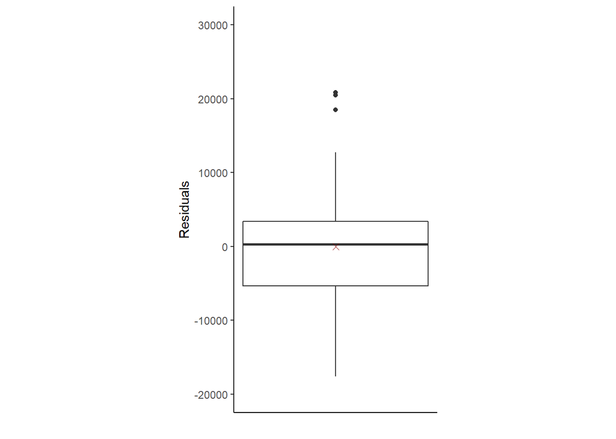

```r
# Boxplot
ggplot(data = water, mapping = aes(y = Resid)) +
  geom_boxplot() +
  stat_summary(mapping = aes(x = 0),
               fun = mean, geom = "point",
               shape = 4, size = 2, color = "darkred") +
  theme_classic() +
  theme(aspect.ratio = 2,
        axis.text.x = element_blank(),
        axis.ticks.x = element_blank()) +
  scale_y_continuous(limits = c(-20000, 30000), breaks = seq(-20000, 30000, 10000)) +
  ylab("Residuals") +
  xlab("")
```

The residuals certainly could be better and I might look at some transformations, but they look normal enough. This assumption is met.

#### 9. (E) The residuals have equal (constant) variance across all values of $X$ (homoscedastic) (use two diagnostic tools)

```r
# Residuals vs Fitted Values
water.resid_fit
```

[output not shown]

```r
# Brown-Forsyth Test
grp <- as.factor(c(rep("lower", floor(dim(water)[1] / 2)),
                   rep("upper", ceiling(dim(water)[1] / 2))))
leveneTest(arrange(water, Precip)$Resid ~ grp, center = median)
```

```
## Levene's Test for Homogeneity of Variance (center = median)
##       Df F value Pr(>F)
## group  1  0.9582 0.3334
##       41
```

#### 10. (A) The model describes all observations (i.e., there are no influential points) (use at least four diagnostic tools)

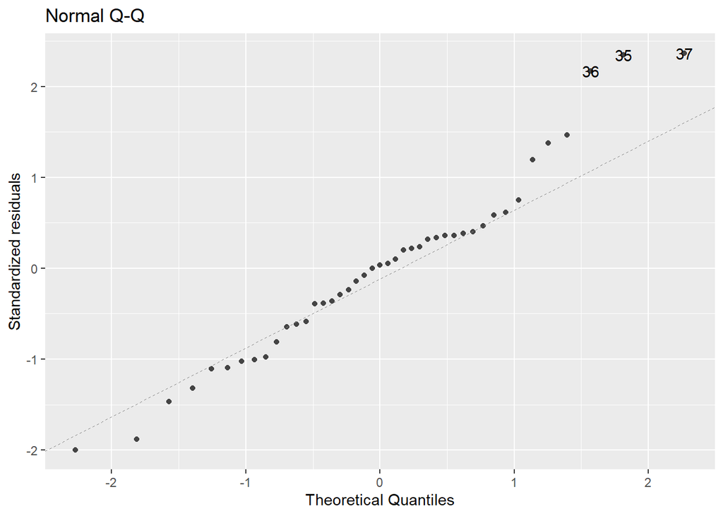

```r
#Q-Q
water.qq
```

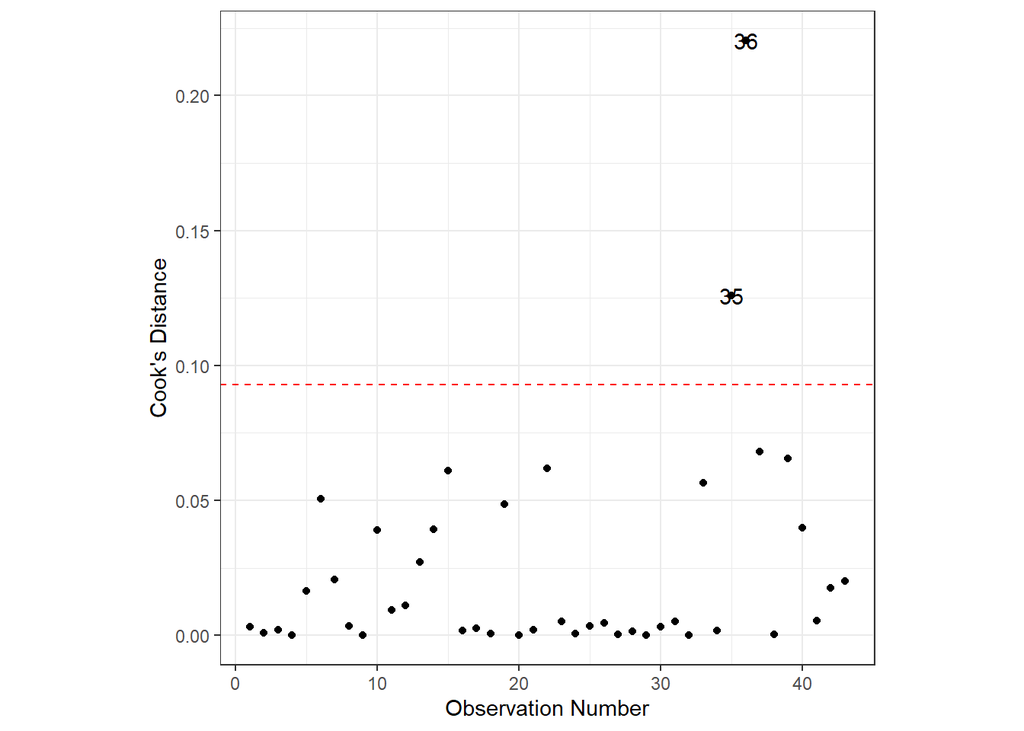

```r
# Cook's Distance
water <- water %>% mutate(cooksd = cooks.distance(water.lm))
top2cd <- as.numeric(names(sort(water$cooksd, decreasing = TRUE)[1:2]))

ggplot() +
  geom_point(data = water,
             mapping = aes(x = as.numeric(rownames(water)),
                           y = cooksd)) +
  geom_text(mapping = aes(x = top2cd,
                          y = water$cooksd[top2cd],
                          label = top2cd)) +
  theme_bw() +
  ylab("Cook's Distance") +
  xlab("Observation Number") +
  geom_hline(mapping = aes(yintercept = 4 / length(water$cooksd)),
             color = "red", linetype = "dashed") +
  theme(aspect.ratio = 1)
```

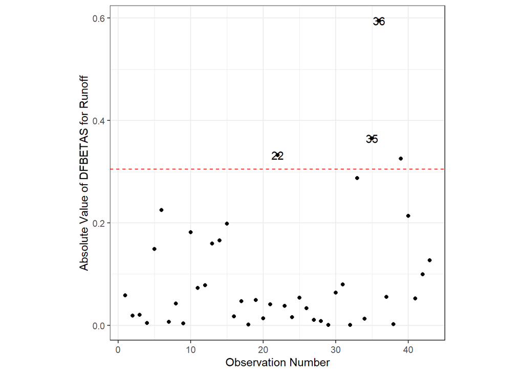

```r
# DFBETAS
water <- water %>%
  mutate(dfbetas_precip = dfbetas(water.lm)[, "Precip"])
names(water$dfbetas_precip) <- 1:nrow(water)
top3dfbeta <- as.numeric(names(
  sort(abs(water$dfbetas_precip), decreasing = TRUE)[1:3]
))

# Plot the DFBETAS against the observation number
ggplot() +
  geom_point(data = water,
             mapping = aes(x = as.numeric(rownames(water)),
                           y = abs(dfbetas_precip))) +
  geom_text(mapping = aes(x = top3dfbeta,
                          y = abs(water$dfbetas_precip[top3dfbeta]),
                          label = top3dfbeta)) +
  theme_bw() +
  ylab("Absolute Value of DFBETAS for Runoff") +
  xlab("Observation Number") +
  geom_hline(mapping = aes(yintercept = 2 / sqrt(length(water$dfbetas_precip))),
             color = "red", linetype = "dashed") +
  theme(aspect.ratio = 1)
```

```r
#Resid vs Fitted
water.resid_fit
```

[output not shown]

This assumption is not met, we would want to at least look at points 35 and 36 that show up in all the plots. Maybe 37 too.

#### 11. (R) Additional predictor variables are not required (no diagnostic tools - just think about the variables you have and if there are other variables you think would help predict the response)

This assumption is met. While it is possible that there are other predictors of runoff than snowfall, they must have a small impact in comparison.

### Based on your answers to questions 6 through 11, you may (or may not) have decided a transformation to the data is needed. This was, hopefully, good practice for assessing model assumptions. For simplicity for this assignment, we will use the orignial model (no transformations) for the rest of the questions. While this may be less satisifying, it will save you time.:)

#### 12. Mathematically write out the fitted simple linear regression model for this data set using the coefficients you found above (do not use betas). Do not use “X” and “Y” in your model - use variable names that are fairly descriptive.

$\widehat{\text{Runoff}}_i=27014.6+3752.5\cdot\text{Precip}_i$

#### 13. Compute, print, *and interpret* a 95% confidence interval for the slope.

```r
confint(water.lm, "Precip")
```

```
##           2.5 %   97.5 %
## Precip 3316.809 4188.162
```

If snowfall increases by 1 inch, we are 95% confident that the increase in runoff will be between 3317 and 4188 acre-feet.

#### 14. Based on the confidence interval, does an increase in snowfall *significantly* increase stream water? Why or why not?

Yes, because the null hypothesis of $\beta_1=0$ is not in the interval.

#### 15. Print a summary of the linear model. Interpret the results from the hypothesis test output for the slope.

```r
summary(water.lm)
```

```
##
## Call:
## lm(formula = Runoff ~ Precip, data = water)
##
## Residuals:
##      Min       1Q   Median       3Q      Max
## -17603.8  -5338.0    332.1   3410.6  20875.6
##
## Coefficients:
##             Estimate Std. Error t value Pr(>|t|)
## (Intercept)  27014.6     3218.9   8.393 1.93e-10 ***
## Precip        3752.5      215.7  17.394  < 2e-16 ***
## ---
## Signif. codes:  0 '***' 0.001 '**' 0.01 '*' 0.05 '.' 0.1 ' ' 1
##
## Residual standard error: 8922 on 41 degrees of freedom
## Multiple R-squared:  0.8807, Adjusted R-squared:  0.8778
## F-statistic: 302.6 on 1 and 41 DF,  p-value: < 2.2e-16
```

The p-value of $2.2\times10^{-16}$ is very small, so we conclude that there is a linear correlation between precipitation and runoff.

#### 16. Briefly describe the difference between (1) a confidence interval for the slope, (2) a confidence interval for the mean of $Y$, and (3) a prediction interval for individual observations.

A confidence interval for the slope tells you where we think the true slope will lie. The CI for the mean of y tells us where we think the true mean of y for a specific value of x is. The prediction interval tells us where we think a new observation will lie based on it’s x value.

#### 17. Compute, print, *and interpret* a 95% confidence interval for the average of $Y$ when $x_i=30$.

```r
predict(water.lm, newdata = data.frame(Precip = 30),
        interval = "confidence", level = 0.95)
```

```
##        fit      lwr      upr
## 1 139589.2 131902.2 147276.1
```

We are 95% confident that the average runoff for all years with 30 inches of precipitation is between 131902.2 and 147276.1 acre-feet.

#### 18. Create a confidence band for the average of $Y$ across all values of $X$, and overlay this band (using a distinct color) on your previous scatterplot that you created in 4. Print the plot.

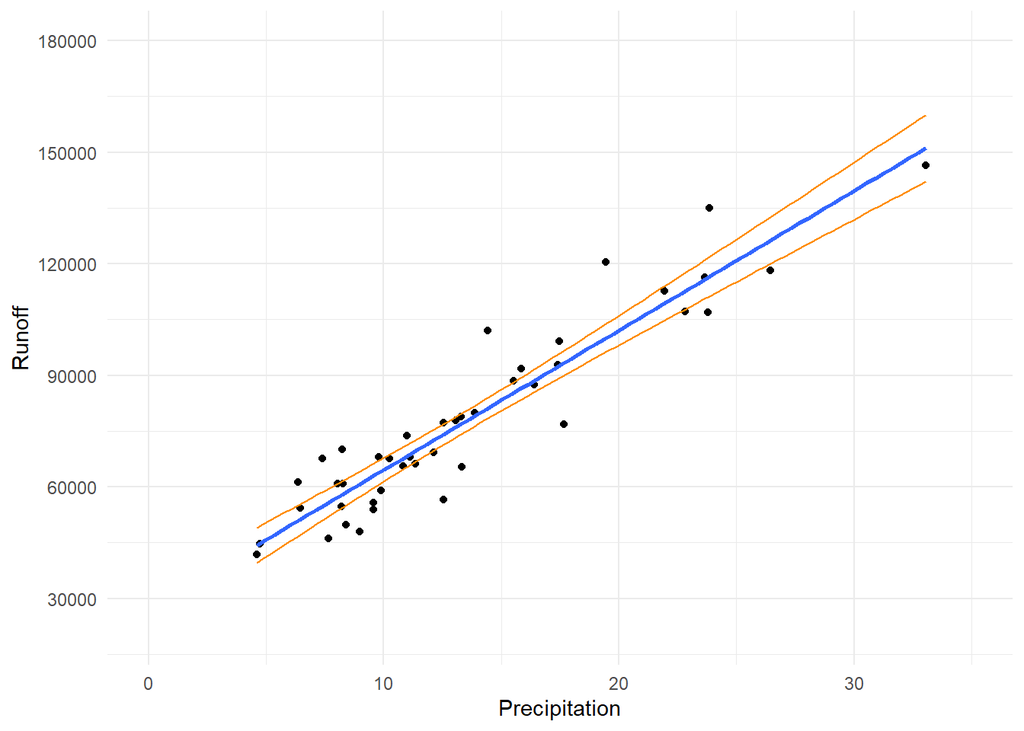

```r
values <- tibble(
  Precip = seq(min(water$Precip), max(water$Precip), length = 100))
values <- values %>%
  mutate(Runoff = predict(water.lm,
                          newdata = values,
                          interval = "confidence",
                          level = 0.95))
(water.CIplot <- water.plot +
  geom_smooth(method = "lm", se = FALSE) +
  geom_line(data = values,
            mapping = aes(x = Precip, y = Runoff[,"lwr"]),
            color = "darkorange") +
  geom_line(data = values,
            mapping = aes(x = Precip, y = Runoff[,"upr"]),
            color = "darkorange"))
```

```r
# Alternatively
# water.plot + geom_smooth(method = "lm")
```

#### 19. Briefly explain why the confidence band is shaped the way that it is.

The calculation of the confidence interval depends on how far from the mean of x you are. As you get farther from the mean of x you get more uncertain.

#### 20. Compute, print, *and interpret* a 95% prediction interval for $Y$ when $x_i=30$.

```r
predict(water.lm, newdata = data.frame(Precip = 30),
        interval = "prediction", level = 0.95)
```

```
##        fit      lwr      upr
## 1 139589.2 119998.8 159179.5
```

We are 95% confident if we measured the precipitation one year to be 30 inches that the runoff would be between 119998.8 and 159179.5 acre-feet.

#### 21. Create a prediction band for $Y$ across all values of $X$, and overlay this band (using a distinct color) on your previous scatterplot that you created in 4. Print the plot.

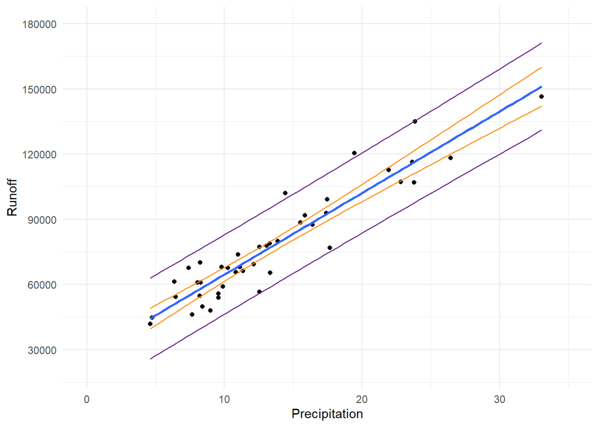

```r
values <- tibble(
  Precip = seq(min(water$Precip), max(water$Precip), length = 100))
values <- values %>%
  mutate(Runoff = predict(water.lm,
                          newdata = values,
                          interval = "prediction",
                          level = 0.95))
water.CIplot +
  geom_smooth(method = "lm", se = FALSE) +
  geom_line(data = values,
            mapping = aes(x = Precip, y = Runoff[,"lwr"]),
            color = "darkorchid4") +
  geom_line(data = values,
            mapping = aes(x = Precip, y = Runoff[,"upr"]),
            color = "darkorchid4")
```

#### 22. Briefly explain how/why the prediction band differs from the confidence band.

The confidence band shows where the mean runoff might fall (a fixed parameter). The prediction band shows where a data point might fall (a random variable).

#### 23. Calculate the MSE (Mean Square Error) for the linear model you fit using the ANOVA results. Print the result.

```r
(water.mse <- sum(water$Resid^2) / water.lm$df.residual)
```

```
## [1] 79610011
```

#### 24. Briefly explain (1) what the MSE estimates and (2) a drawback to using it as a model evaluation metric.

The MSE estimates the mean variance of the model. The main drawback is that it is very un-interpretable.

#### 25. Calculate the RMSE (Root Mean Square Error) for the linear model you fit. Print and interpret the result.

```r
(water.rmse <- sqrt(water.mse))
```

```
## [1] 8922.444
```

#### 26. Calculate the MAE (Mean Absolute Error) for the linear model you fit (do not use a function from a random R package). Print and interpret the result.

```r
sum(abs(water$Resid)) / water.lm$df.residual
```

```
## [1] 6954.957
```

#### 27. Briefly explain a benefit of using the MAE as a model evaluation metric over the RMSE.

The MAE is much less sensitive to outliers since the residuals are not being squared.

#### 28. Print a summary of the linear model. Briefly interpret the R-Squared (Coefficient of Determination) value.

```r
summary(water.lm)
```

```
##
## Call:
## lm(formula = Runoff ~ Precip, data = water)
##
## Residuals:
##      Min       1Q   Median       3Q      Max
## -17603.8  -5338.0    332.1   3410.6  20875.6
##
## Coefficients:
##             Estimate Std. Error t value Pr(>|t|)
## (Intercept)  27014.6     3218.9   8.393 1.93e-10 ***
## Precip        3752.5      215.7  17.394  < 2e-16 ***
## ---
## Signif. codes:  0 '***' 0.001 '**' 0.01 '*' 0.05 '.' 0.1 ' ' 1
##
## Residual standard error: 8922 on 41 degrees of freedom
## Multiple R-squared:  0.8807, Adjusted R-squared:  0.8778
## F-statistic: 302.6 on 1 and 41 DF,  p-value: < 2.2e-16
```

#### 30. Look at the F-Statistic and corresponding $p$-value from the summary of the linear model (output shown above). Do these values indicate that $X$ has a statistically significant linear association with $Y$?

Yes, the f-statistic is very large and the p-value is very, very small indicating that there is a strong linear association between x and y.

#### 31. Briefly summarize what you learned, personally, from this analysis about the statistics, model fitting process, etc.

My main takeaway from this assignment was a solid understanding of the prediction and confidence intervals.

#### 32. Briefly summarize what you learned from this analysis *to a non-statistician*. Write a few sentences about (1) the purpose of this data set and analysis and (2) what you learned about this data set from your analysis. Write your response as if you were addressing a business manager (avoid using statistics jargon) and just provide the main take-aways.

The purpose of this analysis was to evaluate whether there is a correlation between the precipitation in the Sierra-Nevadas and the water runoff in Bishop, CA. We determined that is is a very strong correlation between the two, that as precipitation increases so does runoff, and that if we know the precipitation for any given year we can predict the runoff with an accuracy of about plus or minus 17,000 acre-feet.